# Coursework Report

*N* removed NAs: 2

*N* removed typo: 1

*N* removed <18: 26

*N* total clean: 121

| Group | *N* | *M*<sub>age</sub> | *M*<sub>rating</sub> |
| --- | --- | --- | --- |
| Control | 57 | 20.81 | 5.53 |
| Experim | 64 | 21.31 | 6.67 |

**Main analysis results**

*t*(119) = -8.66, *p* < .001

[interactive chart not shown]

[figure not shown]

[interactive chart not shown]

# Coursework Report

Analysing Data, Spring 2020

# Methods

## Participants

Figure 1: *Descriptive Statistics by Condition*

| Condition | *N* | % | *M*<sub>age</sub> | *SD*<sub>age</sub> |
| --- | --- | --- | --- | --- |
| control | 56 | 48.28 | 20.71 | 1.86 |
| experimental | 60 | 51.72 | 20.97 | 1.80 |

## Design

The main purpose of this research is to investigate whether the results from Elliot et al’s (2010) study “Red, Rank and Romance in Women viewing Men” are replicable. It will be testing if women are influenced by the colour red when judging the perceived attractiveness of a man in a photograph (Elliot et al, 2010). To test this concept, a black and white male photograph is presented on either a white or red background. To measure the influence colour has on the male’s attractiveness, participants answered 3 questions, all taken from Elliot et al’s original 2010 study;

- How attractive do you think this person is?
- How pleasant is this person to look at?
- If you met this person face to face, would you think they are attractive?

Each question was answered using a 9-point likert scale. A rating scale is a standardised way of measuring perceived attractiveness, as a low rating score of 1 deemed the man not attractive at all, whilst a score of 9 indicated that they were perceived to be extremely attractive. A *t*-test will be used to statistically analyse the data collected from the participants. Data collected from this study will test the operationalised hypothesis ‘women will give a man’s photograph a higher attractiveness rating out of 9 when he is seen in conjunction with the colour red, as opposed to the colour white’.

# Results

All data collected from 116 participants was used in the analysis process as there were no obvious outliers. All results conformed to the 9-point likert scale range used in the experiment. The overall mean for the “white” control group was 5.53 , and the mean for the “red” experimental group was 6.64. The difference of 1.11 between these two means immediately suggests that the hypothesis will be supported by my data as this value is relatively large, however a *t*-test and other statistical analysis has been conducted to provide sufficient evidence for this claim. In order to ensure that each question used in the experiment had accurately measured the same variable of “attractiveness”, the data from each question was plotted against each other. Figure 2, Figure 3 and Figure 4 demonstrate the relationships between scores for the respective questions:

- Question 1: How attractive do you think this person is?
- Question 2: How pleasant is this person to look at?
- Question 3: If you met this person face to face, would you think they are attractive?

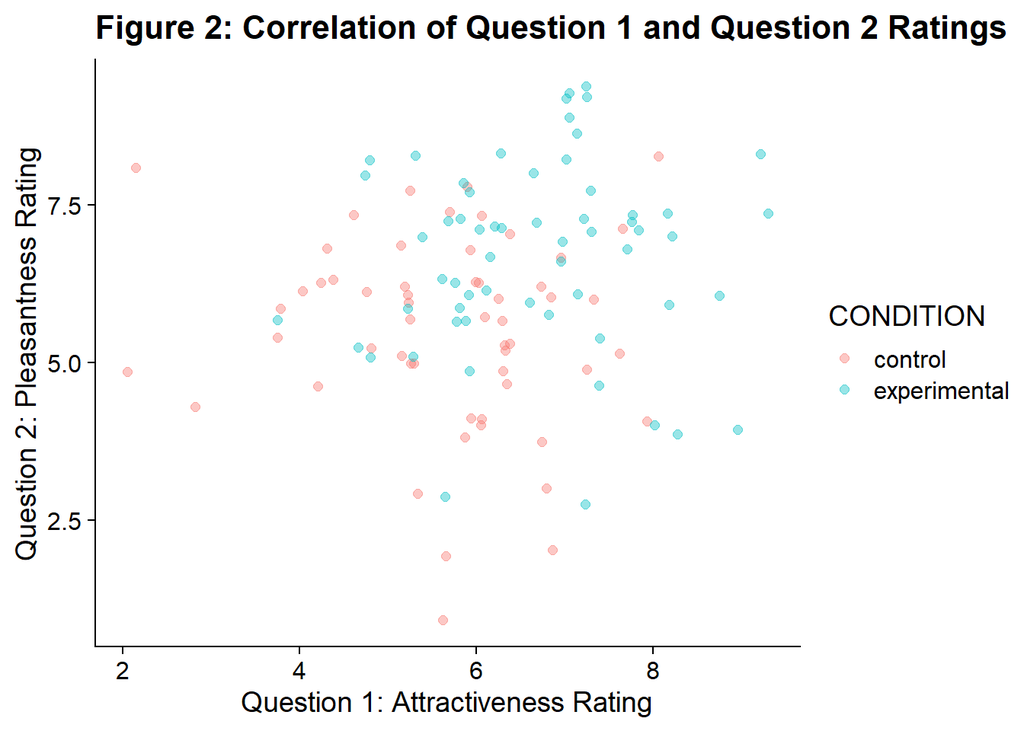

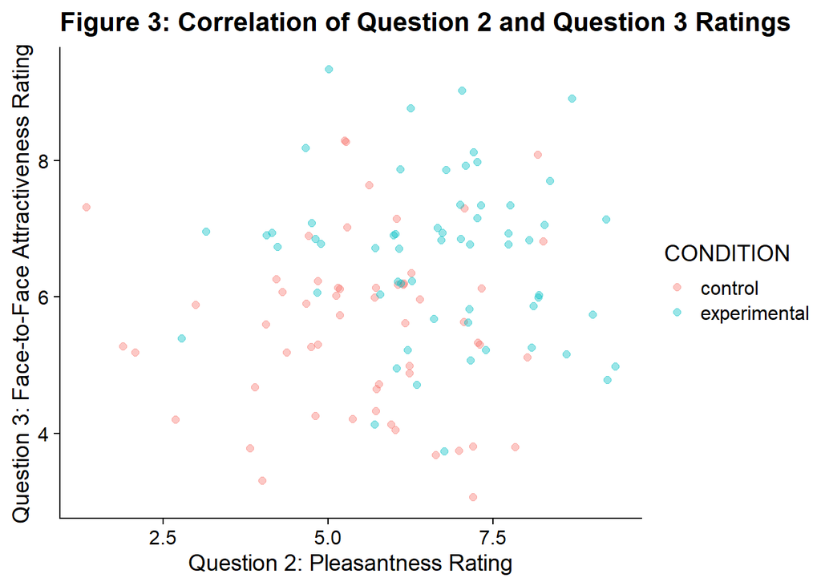

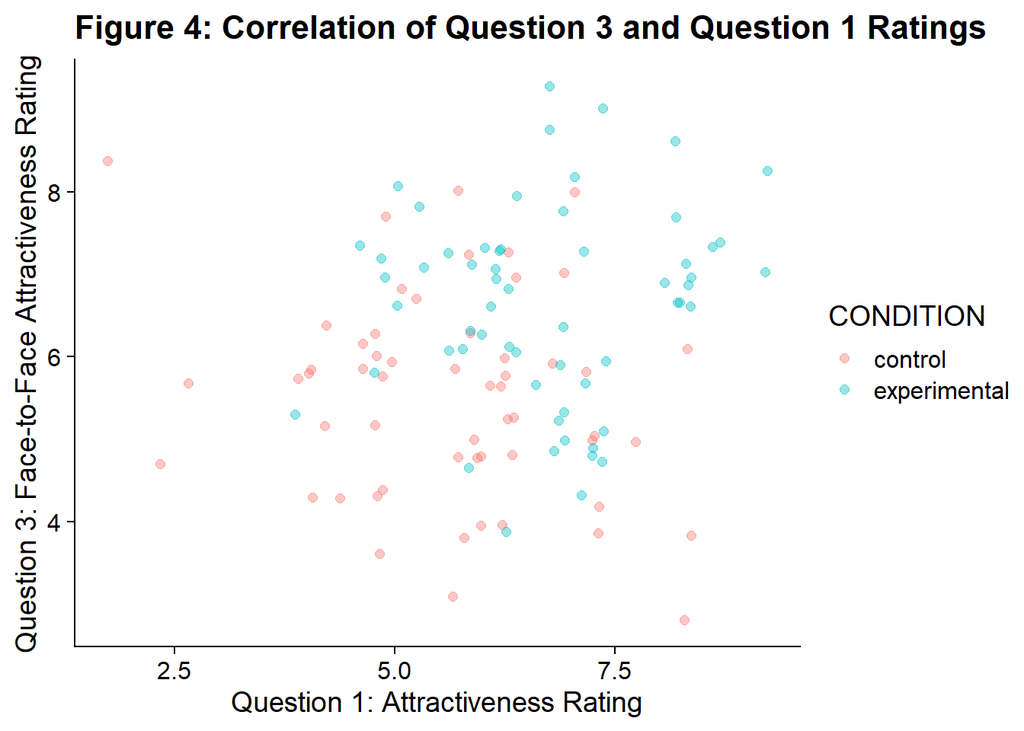

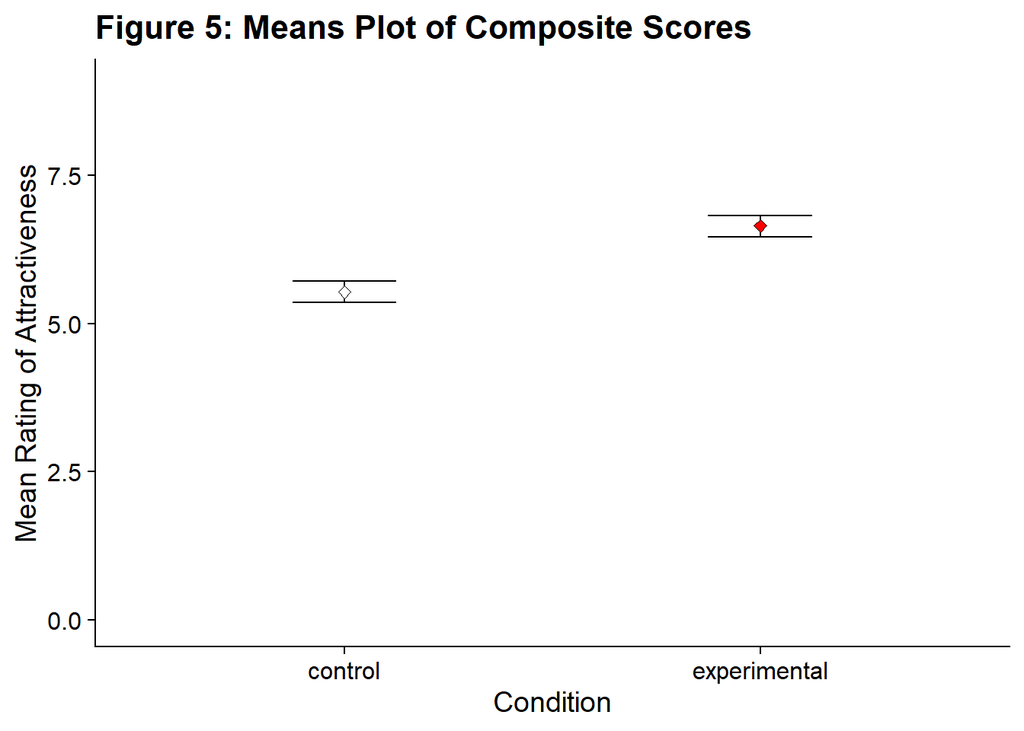

# Discussion

In summary, the investigation of whether women would rate the perceived attractiveness of a male’s photograph differently depending on whether he was presented on top of a coloured background or not, was supported by significant evidence found in my replication of Elliot et al’s 2010 study. The control group saw a white background (no colour presented behind the image), whilst the experimental group saw the introduction of a red coloured background behind the image of the same man. The experimental group consistently gave the man higher attractiveness ratings and the significant difference between the two condition means demonstrates that this is likely to be strongly correlated with the presentation of the colour red.

A variety of replication studies have been conducted and found very different results to Elliot et al’s original research (2010). My data follows a similar pattern to the original conclusions, finding a significant relationship between the effect of colour presentation on perceived male attractiveness. Similar adaptation studies have also been conducted using the effect of reading the word “red” as opposed to visibly seeing it, and have found similar results which suggest that universally “red” has a significant impact on women’s opinions of men (Pazda & Elliot, 2017). However, other research has attempted to replicate this “red effect”, and many have been unsuccessful at being able to get similar results. It has been suggested that Elliot et al’s (2010) investigation of the colour red influencing the perception of men’s attractiveness may not have proper supporting evidence and therefore, may not make the study’s hypothesis authentically endorsed properly (Francis, 2013). Replications have used a larger sample size and found contradicting results to the original (Peperkoorn et al, 2016). This would suggest that having a small sample size of twenty-one (Elliot et al, 2010) or even my sample of one-hundred and sixteen does not provide sufficient data upon which to analyse the effects of colour influencing attractiveness. Peperkoorn et al’s (2016) research had a larger criterion of ages for participants, from ages eighteen to forty. Their research is therefore likely to be more accurate when applied to a wider population as the overall quantity of participants (two-hundred and six), and subsequent range of participant’s ages are larger. The data I collected and Elliot et al’s (2010) is very narrow, with limited participants in a small age bracket. This is not ideal as small samples are more susceptible to error in analysis, often rejecting the null hypothesis when it is in fact true (Colquhoun, 2014). An age range of eighteen to twenty-five-year olds is a very specific category of people to analyse and therefore the outcomes of the study are likely to be highly biased by younger people’s opinions of what is deemed “attractive”. Furthermore, the lack of older age representation will make this data hard to apply to a larger population, as many women of different generations will have vastly different opinions on what is attractive and what certain colours may mean to them.

As my research was only conducted using female participants, in order to accurately represent society, the study could also be replicated using only male participants to test whether colours are universal at influencing people’s perception of attractiveness. Peperkoorn et al’s (2016) research used male participants, which may have influenced the dramatic difference in the overall outcome results in comparison to Elliot et al’s. Studying the effects of colour influencing different genders, as well as a larger age range in the aforementioned paragraph, will allow us to access wider and more accurate implications for application to a vast community. Classical conditioning (Bitterman, 2006) and general conditioning from implied societal normalities have been suggested to affect people’s perception of colour in relation to many things, including attractiveness (Elliot et al, 2013). This research on the effects of colour presentation is primarily useful for marketing and the advertisement of products. In order to increase sales, many companies use specific colours to entice customers and to set their product apart from others, as well as indirectly link certain symbolism to the colour (Sliburyte et al, 2014) and therefore product too. However, gender shouldn’t be a significant variable within this area of research, as when applying results to an everchanging modern society, boundaries that have previously segregated men and women are changing, and it is becoming a spectrum of self- identification instead of binary categories (Juwaheer & Sahye, 2019). With a modern world, should come modern research and a modern application of findings, however, we cannot achieve this if the research being done is not considering a vast number of the population it is studying. The data collected previously on either men or women is relevant to society still as it gives the foundations upon which we are able to develop research to more specifically identify factors influencing perceived attractiveness, linking it to colour influences, for a broader scale of people within society today. A meta-analysis of replication research of Elliot et al’s (2010) original studies concludes that in addition to only having female participants, any sexual identification, besides heterosexual or bisexuality, were removed from the data set and analyses (Wagge et al (2019). The significance of colour in marketing makes me question whether sexuality should be ignored in analysis, as a variety of products, more now than ever, are attempting to cater for a vast community of social partnering with reference to the significance that the colour ‘red’ holds on occasions such as Valentine’s Day (Francis, 2013). Participants in my research did not have to state their sexuality, so it is unknown whether my data set contains a variety of sexualities, or whether it is solely a heterosexual sample population.

A between groups study design was used in my replication research, so it is unlikely that any of the participants in this reconstruction were able to guess the purpose of the research as they only saw one photograph (identical in each condition) with one colour presented (either red or white). If this were true, the result would be similar to one that the original study got and other replications too (Elliot et al, 2010, Elliot et al, 2012). No baseline data for the opinions of the man’s attractiveness were collected before presenting the photograph alongside coloured backgrounds. Baseline data on attractiveness would be beneficial to collect as it would be possible to see the true influence of colour on the level of attraction. However, this would mean changing the colour presented in the control group as white or a lack of colour, would be presented with the picture in order to get baseline data without influence. Furthermore, if data was collected from a pilot baseline test, participants in each control group could be closely matched for similar opinions of attractiveness ratings which would provide additional validity to the data being analysed. A more direct comparison between conditions could be evaluated and provide stronger support for the null or alternative hypothesis.

and its influence on the perceived attractiveness of men, this data has not been replicated by many others, questioning the publication bias and overall validity of Elliot et al’s findings (2010) (Francis, 2013).

# References

Bitterman, M. (2006). Classical Conditioning Since Pavlov. *Review of General Psychology, 10*(4), 365-376

Colquhoun, D. (2014). An investigation of the false discovery rate and the misinterpretation of p-values.*Royal Society Open Science, 1*(140216)

Elliot, A & Niesta, D. (2008). Romantic Red: Red Enhances Men’s Attraction to Women.*Journal of Personality and Social Psychology, 95*(5), 1150-1164

Elliot, A, et al. (2010). Red, Rank and Romance in Women Viewing Men. *Journal of Experimental Psychology: General, 139*(3), 399-417

Elliot, A, et al. (2012) Red enhances women’s attractiveness to men: First evidence suggesting universality. *Journal of Experimental Social Psychology, 2013*(49). 165-168

Elliot, A & Maier, M. (2013). The Red- Attractiveness Effect, Applying the Ioannidis and Trikalinos (2007b) Test, and the Broader Scientific Context. A Reply to Francis (2013). *Journal of Experimental Psychology: General, 142*(1), 297- 300

Elliot, A. (2015). Colour and psychological functioning: a review of theoretical and empirical work. *Frontiers in Psychology, 6*(368)

Francis, G. (2013). Publication Bias in “Red, Rank and Romandce in Women Viewing Men” by Elliot et al. (2010). *Journal of Experimental Psychology: General, 142*(1), 292-296

Haran, K & Briggs, S. (2016). Red, Rank and Romance in Women viewing Men: A Replication Study. *UC Merced Undergraduate Research Journal, 8*(2)

Hesslinger, V, Goldbach, L & Carbon, C. (2015). Men in red: A reexamination of the red- attractiveness effect. *Psychon Bull Rev, 2015*(22), 1142-1148

Juwaheer, T & Sahye, K. (2019). The Use of Colours in Marketing in Shopping Malls of Mauritius: A Gendered Approach. *Journal of marketing Devlopment and Competitiveness, 13*(3), 68-90

Labrecque, L & Milne, G. (2011). Exciting red and competent blue: the importance of colour in marketing. *Journal of Academy Marketing Science, 2012*(40), 711-727

Lehmann, G & Calin-Jageman, R. (2017). Is Red Really Romantic? *Social Psychology, 48*(3), 174-183

Lehmann, G, Elliot, A & Calin-Jageman, R. (2018). Meta- Analysis of the Effect of Red on Perceived Attractiveness. *Evolutionary Psychology,* 1-27

Pazda, A & Elliot, A. (2017). Processing the Word Red can Enhance Women’s Perception of Men’s Attractiveness. *Curr Psychol, 2017(36), 316-323*

Peperkoorn, L, Roberts, S, Pollet, T. (2016). Revisiting the Red Effect on Attractiveness and Sexual Receptivity: No Effect of the Colour Red on Human Mate Preferences. *Evolutionsary Psychology, 2016*(1), 1-13

Sliburyte, L & Skoryte, I. (2014) What we know about consumers’ colour perception. *Journal of Social and Behavioural Sciences 156*, 468-472

Wagge, J, et al. (2019). A Demonstration of the Collaborative Replication and Education Project: Replication Attempts of the Red-Romance Effect.*Collabra: Psychology, 5*(1)